# Activity Tracker Data Analysis and Prediction

Joe Fuqua

October 21, 2015

# Overview

This assignment takes activity tracker data from this source:

https://d396qusza40orc.cloudfront.net/predmachlearn/pml-training.csv

to build a predictive model that determines the type or ‘classe’ of device for each of the test cases from this source:

https://d396qusza40orc.cloudfront.net/predmachlearn/pml-testing.csv

I have downloaded these files to a local directory to allow for work offline.

# Loading and Inspecting the data

Libraries first:

```r
library(ggplot2)
library(lattice)
library(caret)
library(rattle)
library(randomForest)
```

Early exploratory analysis shows a large number of columns with no data or NA, or #DIV/0. During the load, we will standardize those entries to NA for easier identification later (exploratory graphs omitted to conserve space):

```r
trdata<-read.csv("pml-training.csv",na.strings=c("NA","NULL","#DIV/0",""))
tstdata<-read.csv("pml-testing.csv",na.strings=c("NA","NULL","#DIV/0",""))
```

Some information on the datasets:

```r
str(trdata)
str(tstdata)
```

This shows we have 19,622 observations for training and 20 for testing with 160 variables for each.

# Data Cleansing

Let’s remove columns that are mostly NA, as well as the first 6 columns (row number, time stamp, etc) that are not useful to the model.

```r
remcols <- vector(mode="numeric")

for (i in 1:ncol(trdata)) {
  remcols[i]<- (sum(complete.cases(trdata[,i]))/nrow(trdata) != 1)
}

trdata<-trdata[,!remcols]
trdata<-trdata[,-c(1:6)]
dim(trdata)
```

```
## [1] 19622    54
```

Down to 54 variables, one of which is the variable we are trying to predict, ‘classe’.

# Predictive Model

Okay, time to build our predictive model. Given the variable we are trying to predict (‘classe’) is a factor, let’s use a Random Forest model (after subsetting the training data):

```r
set.seed(1)
trainSegment<-createDataPartition(y=trdata$classe, p=.6, list=FALSE)

subtrain<-trdata[trainSegment,]
subtest<-trdata[-trainSegment,]

dim(subtrain)
```

```
## [1] 11776    54
```

```r
dim(subtest)
```

```
## [1] 7846   54
```

Now the model (note I initially ran the model with the ‘train’ function from the ‘caret’ package, but performance was unacceptable).

```r
#modFit<-train(classe~.,data=subtrain, method='rf',
#                trControl=trainControl(method="cv",number=5),
#                prox=TRUE,allowParallel=TRUE)

modFit<-randomForest(classe~., data=subtrain, nodesize=42, ncores=2)

modFit
```

```
##
## Call:
##  randomForest(formula = classe ~ ., data = subtrain, nodesize = 42,      ncores = 2)
##                Type of random forest: classification
##                      Number of trees: 500
## No. of variables tried at each split: 7
##
##         OOB estimate of  error rate: 1.27%
## Confusion matrix:
##      A    B    C    D    E  class.error
## A 3345    2    0    0    1 0.0008960573
## B   23 2247    9    0    0 0.0140412462
## C    0   45 2003    6    0 0.0248296008
## D    0    1   42 1884    3 0.0238341969
## E    0    2    1   15 2147 0.0083140878
```

So, a fairly good fit with a OOB sample error rate of 1.27%.

A quick look at error rates by predicted value:

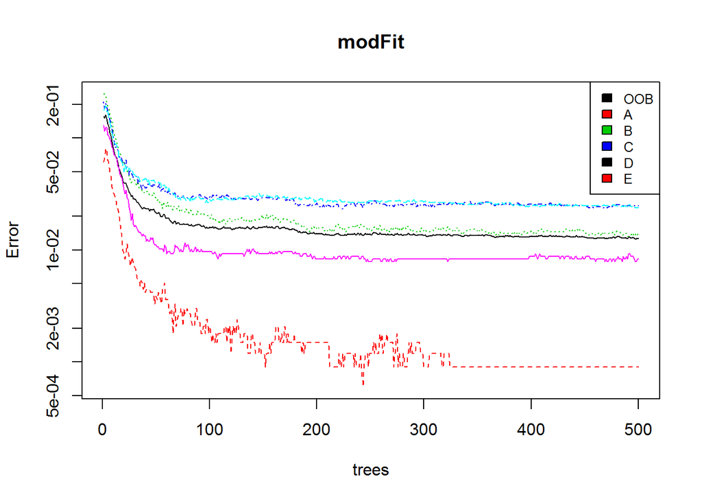

```r
plot(modFit,log='y')
legend('topright',legend=colnames(modFit$err.rate),col=1:5,cex=0.8,fill=1:4)
```

We could simplify the fit by selecting fewer variables that have more influence on the model:

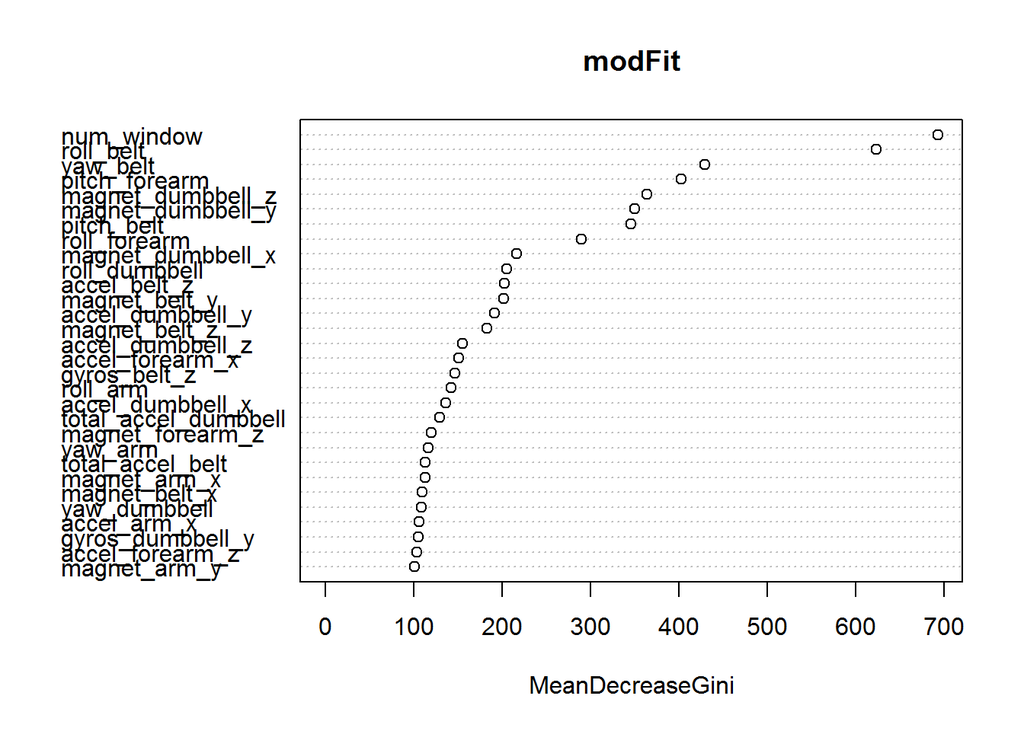

```r
 varImpPlot(modFit,)
```

But this model runs reasonably quickly and appears to be highly accurate.

# Cross Validation

Now run against the subset of test data from the training dataset.

```r
predmodel<-predict(modFit,newdata=subtest)
confusionMatrix(subtest$class,predmodel)
```

```
## Confusion Matrix and Statistics
##
##           Reference
## Prediction    A    B    C    D    E
##          A 2232    0    0    0    0
##          B   14 1495    9    0    0
##          C    0   23 1345    0    0
##          D    0    0   23 1261    2
##          E    0    0    1   14 1427
##
## Overall Statistics
##
##                Accuracy : 0.989
##                  95% CI : (0.9865, 0.9912)
##     No Information Rate : 0.2863
##     P-Value [Acc > NIR] : < 2.2e-16
##
##                   Kappa : 0.9861
##  Mcnemar's Test P-Value : NA
##
## Statistics by Class:
##
##                      Class: A Class: B Class: C Class: D Class: E
## Sensitivity            0.9938   0.9848   0.9761   0.9890   0.9986
## Specificity            1.0000   0.9964   0.9964   0.9962   0.9977
## Pos Pred Value         1.0000   0.9848   0.9832   0.9806   0.9896
## Neg Pred Value         0.9975   0.9964   0.9949   0.9979   0.9997
## Prevalence             0.2863   0.1935   0.1756   0.1625   0.1821
## Detection Rate         0.2845   0.1905   0.1714   0.1607   0.1819
## Detection Prevalence   0.2845   0.1935   0.1744   0.1639   0.1838
## Balanced Accuracy      0.9969   0.9906   0.9862   0.9926   0.9981
```

So, we get a 99% accuracy rate (1% sampling error) on the subset of test data.

# Predition

We are ready to evaluate the actual testing dataset:

```r
# Apply earlier filters to the testing dataset

tstdata<-tstdata[,!remcols]
tstdata<-tstdata[,-c(1:6)]
dim(tstdata)
```

```
## [1] 20 54
```

```r
# run the predictive model


answer<-predict(modFit, newdata=tstdata)
answer
```

```
##  1  2  3  4  5  6  7  8  9 10 11 12 13 14 15 16 17 18 19 20
##  B  A  B  A  A  E  D  B  A  A  B  C  B  A  E  E  A  B  B  B
## Levels: A B C D E
```